# Cointegration and Error Correction

Module 10 · A night out with Harry, Karen, and Mouse

Gary Cornwall

Econ 6376 · The George Washington University

# Act I · Last call

Three characters. Two relationships to investigate.

## Where we are

$$y_t=\alpha+\sum_{j=1}^{p}\phi_jy_{t-j}
+\sum_{\ell=0}^{q}\beta_\ell x_{t-\ell}+\epsilon_t$$

| Mixing-board channel | Today |
| --- | --- |
| Intercept, outcome memory, predictor lags | Keep the ARDL framework |
| Explicit MA terms and deterministic trend | Off in our baseline relation |
| Connection between I(1) levels | Ask whether a stationary combination exists |

**Module 9:** does one history help predict another?

What if the levels wander, but their relationship does not?

## Harry and his puppy meet Karen at the bar

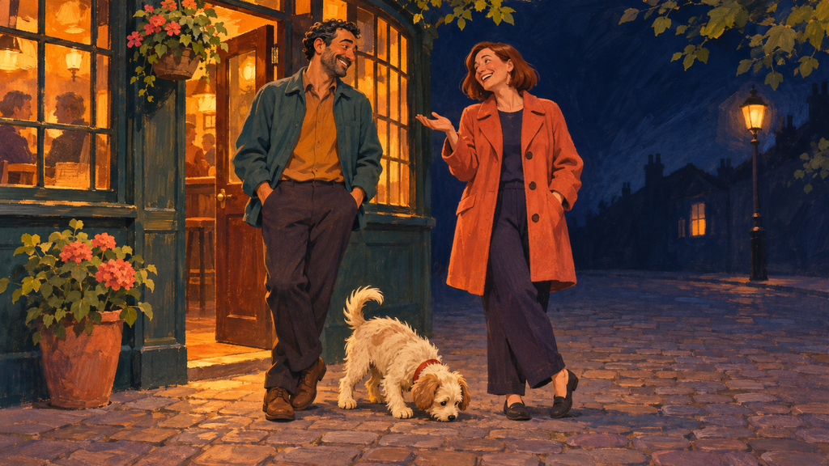

Harry · Karen · Mouse

## A drunk walks. A puppy follows every new scent.

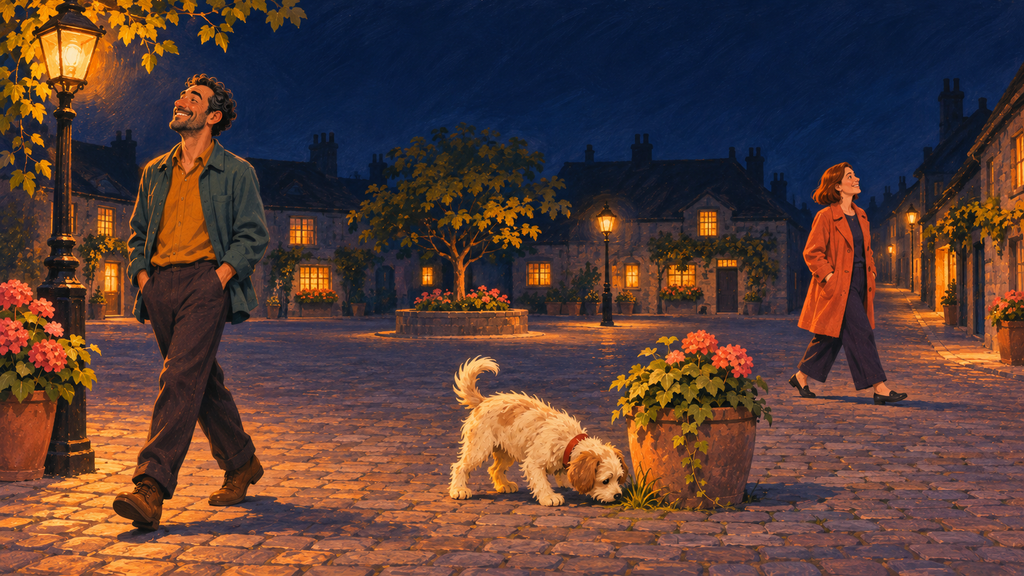

If I lose sight of each one, how uncertain is the next location?

## Harry notices Mouse. Mouse hears Harry.

$$\begin{aligned}
\Delta H_t&=a(M_{t-1}-H_{t-1})+\epsilon_t^H\\
\Delta M_t&=-b(M_{t-1}-H_{t-1})+\epsilon_t^M\\
\Delta K_t&=\epsilon_t^K
\end{aligned}$$

Mouse is ahead. Which way does each correction point?

The gap can influence the next step. New shocks still matter.

## Build the next step

```r
gap <- mouse[t] - harry[t]
harry[t + 1] <- harry[t] + 0.1 * gap + shocks[t, 1]
mouse[t + 1] <- mouse[t] - 0.1 * gap + shocks[t, 2]
karen[t + 1] <- karen[t]             + shocks[t, 3]
```

Same shocks, different rules. Keep 240 observations after 1,000 initial steps.

Predict three plots: locations, changes, and the gap.

## Where did everyone go?

**Static reference: baseline paths**

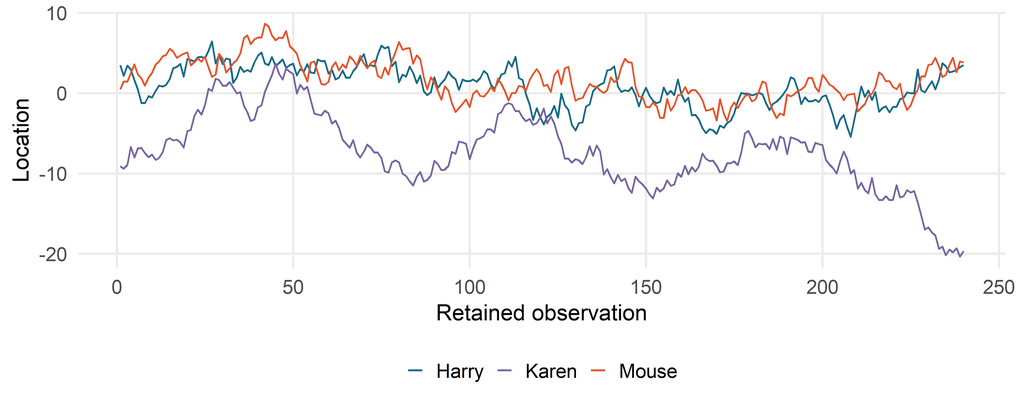

Baseline: correction 0.20, long-run slope 1.00; the same path used in the notes.

[interactive chart not shown]

A random walk can look stable over a short window. Extend the walk; appearance alone is not a test.

# Act II · What stays stable?

Keep your eye on the relationship.

## Their steps are noisy

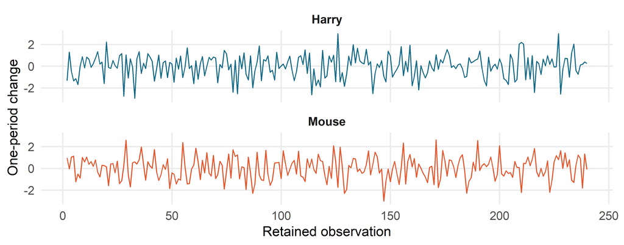

A model of changes alone has no explicit measure of how far apart they are.

## Their separation tells a different story

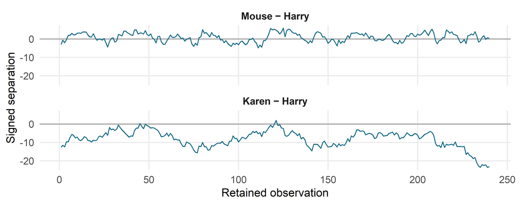

Which object wanders? Which object fluctuates around a stable relationship?

## This is cointegration

$$x_t\sim I(1),\qquad y_t\sim I(1)$$

$$\boxed{z_t=y_t-c-\kappa x_t\sim I(0)}$$

The individual levels wander. A **fixed weighted combination** is stationary.

For Harry and Mouse: $y=M$, $x=H$, $c=0$, $\kappa=1$.

Name the stationary object.

## The weights matter

Suppose $x_t$ is I(1) and $z_t$ is I(0):

$$y_t=2+3x_t+z_t.$$

Would you plot $y_t-x_t$ or $y_t-2-3x_t$?

$$y_t-x_t=2+2x_t+z_t\quad\text{still contains the wandering component.}$$

Return to the walkers: change the long-run slope

## What the story does not establish

| Tempting shortcut | What we still need |
| --- | --- |
| “They have a high correlation.” | A stationary combination of I(1) levels |
| “Both trend upward.” | Stochastic trends, not just deterministic growth |
| “The gap is stationary.” | Not necessarily white noise, small, or bounded |
| “Harry is on the right-hand side.” | Separate assumptions for exogeneity and causation |

Could they be connected without moving in the same direction?

## Murray’s other story: the teeter-totter

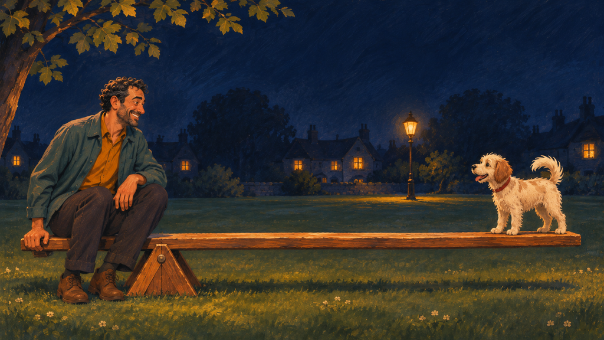

A weighted sum can be stable. The long-run slope can be negative.

# Act III · Would we detect it?

In a simulation we know the relationship. In data we estimate and test it.

## Estimate the relationship before testing it

$$M_t=\hat c+\hat\kappa H_t+e_t,
\qquad e_t=M_t-\hat c-\hat\kappa H_t$$

```r
levels_fit <- lm(Mouse ~ Harry, data = connected)
e <- residuals(levels_fit)
```

Then make the same comparison for **Karen on Harry**.

Did fitting a line remove the wandering part?

## Same operation. Different residual paths.

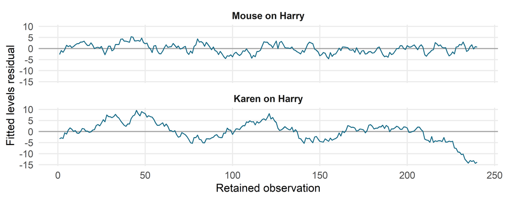

A suggestive plot—or sufficient evidence?

## Engle–Granger: test the estimated deviation

$$\Delta e_t=\gamma e_{t-1}
+\sum_{j=1}^{p_e}\psi_j\Delta e_{t-j}+\epsilon_t^{ADF}$$

$$H_0:\text{no cointegration}\qquad H_1:\text{stationary combination}$$

$$\tau_{EG}=\frac{\hat\gamma}{\widehat{\operatorname{se}}(\hat\gamma)}$$

More negative values favor reversion. Lagged differences address short-run dependence.

## Same t-ratio. A different reference distribution.

The residual was **chosen by fitting the levels relationship**.

Ordinary regression t-values and ordinary ADF critical values do not calibrate this test.

```r
test <- eg_test(y = connected$Mouse, x = connected$Harry,
                p_adf = 1)
c(statistic = test$statistic, critical_5pct = test$cv5)
```

This helper: two variables · intercept, no trend · 5% Engle–Granger reference.

## Harry and Mouse pass this test. Karen does not.

| Relation | EG statistic | 5% critical value | Decision |
| --- | --- | --- | --- |
| Mouse on Harry | -4.767 | -3.362 | Reject no cointegration |
| Karen on Harry | -0.598 | -3.362 | Do not reject |

240 levels observations · one lagged residual difference in each test.

Rejection supports cointegration under the specification. Nonrejection is not proof of absence.

## Turn down the response. Then turn it off.

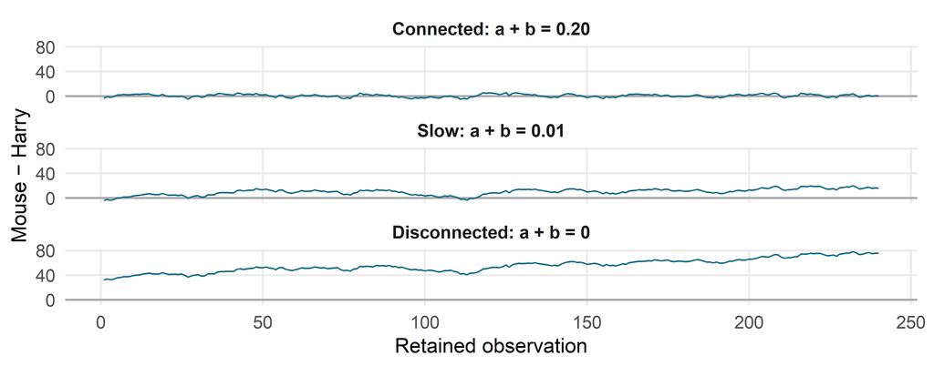

Which change alters the population property? Which makes it harder to detect?

Replay the walkers with weak correction or correction off

## A stable relationship can evade a short sample

| World | Cointegrated in DGP? | EG statistic | Reject at 5%? |
| --- | --- | --- | --- |
| Connected | Yes | -4.767 | Yes |
| Slow | Yes | -2.731 | No |
| Disconnected | No | -2.357 | No |

Common 5% critical value: **-3.362**.

Slow adjustment creates a power problem here. The test does not change the DGP.

# Act IV · OK… now what?

We identified the relationship. Can it tell us about the next step?

## The call and response

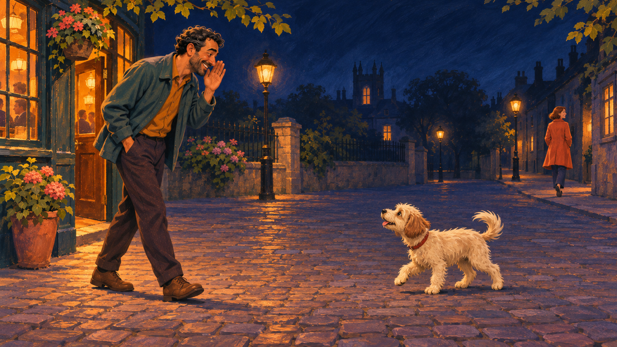

Yesterday’s separation helps explain today’s movement.

## Mouse is ahead. What does the correction contribute?

$$z_{t-1}=M_{t-1}-H_{t-1},\qquad
\Delta M_t=-0.1z_{t-1}+\epsilon_t^M$$

| Previous gap | Mouse’s correction |
| --- | --- |
| $+2$ | $-0.2$ |
| $-2$ | $+0.2$ |

Must the observed gap shrink by 10%?

## We already know the starting model

$$y_t=\alpha+\phi_1y_{t-1}+\beta_0x_t+\beta_1x_{t-1}+\epsilon_t$$

Subtract $y_{t-1}$ and write $x_t=x_{t-1}+\Delta x_t$:

$$\Delta y_t=\alpha+(\phi_1-1)y_{t-1}
+(\beta_0+\beta_1)x_{t-1}+\beta_0\Delta x_t+\epsilon_t.$$

Can we collect the two lagged levels into yesterday’s gap?

## The same equation, with the relationship visible

$$\Delta y_t=\lambda\underbrace{(y_{t-1}-c-\kappa x_{t-1})}_{\text{previous deviation}}
+\beta_0\Delta x_t+\epsilon_t$$

$$\lambda=\phi_1-1,\qquad
c=\frac{\alpha}{1-\phi_1},\qquad
\kappa=\frac{\beta_0+\beta_1}{1-\phi_1}\quad(\phi_1\ne1).$$

**Error correction:** short-run changes plus a response to yesterday’s deviation.

The rearrangement is algebra. A stationary deviation supplies the cointegration interpretation.

## Estimate Mouse’s response

```r
ecm_fit <- lm(dm ~ e_lag + dh, data = ecm_data)
```

$$\Delta M_t=0.014
-0.151e_{t-1}
-0.060\Delta H_t+e_t^{ECM}$$

Here $e_{t-1}=M_{t-1}-\hat c-\hat\kappa H_{t-1}$.

True Mouse adjustment: **−0.100**. Estimated adjustment: **-0.151**.

## A larger gap gives a larger corrective contribution

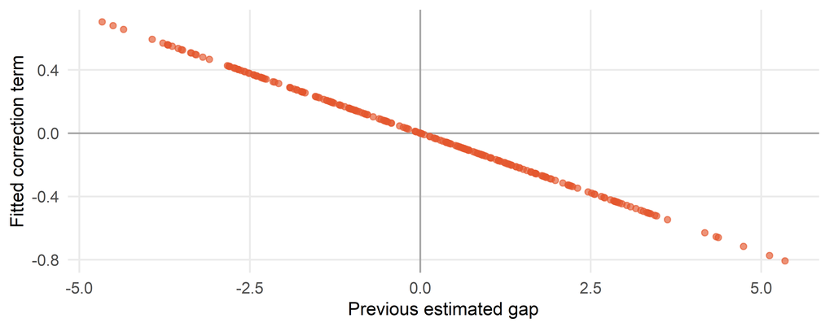

This plots one fitted term—not the whole observed change.

## Who adjusts is a separate question

- Harry could wander freely while Mouse does the correcting.
- A weak response in one equation does not refute a relationship.
- A negative coefficient alone does not establish cointegration or system stability.
- A predictive adjustment is not automatically a policy effect.

If only Mouse responds, does that make Harry exogenous for every question?

# Act V · Back to economics

An appealing story gives us a question. The data still get a vote.

## Economists look for relationships that can persist

| Candidate relationship | What has been learned? |
| --- | --- |
| Consumption and income | Engle–Granger (1987) find evidence in their historical sample |
| Long and short interest rates | Their yield example also supports a long-run relation |
| Purchasing-power parity | Hamilton’s U.S.–Italy example finds little evidence |

Use cointegration to **assess a proposition, estimate a relation, and retain it in dynamics**.

Does finding some slope establish the slope the theory requires?

## Do U.S. consumption and income share a stable log relation?

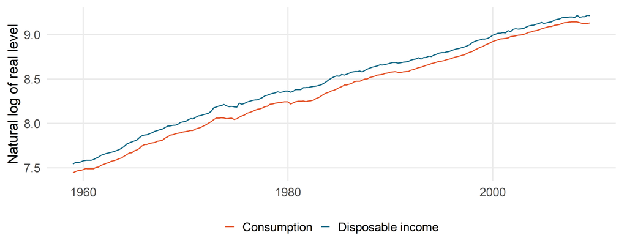

1959Q1–2009Q3 · aggregate real total consumption and disposable income · 203 quarters · December 2009 archive

## First: is I(1) a defensible working description?

| Series | Deterministics | ADF statistic | 5% critical value |
| --- | --- | --- | --- |
| Log consumption | Intercept + trend | -2.435 | -3.43 |
| Log income | Intercept + trend | -1.908 | -3.43 |
| Change in log consumption | Intercept | -5.082 | -2.88 |
| Change in log income | Intercept | -6.351 | -2.88 |

Four lagged differences in each individual-series test.

Levels do not reject; changes do. This supports a working I(1) setup—not proof.

## An excellent fit can leave the question unresolved

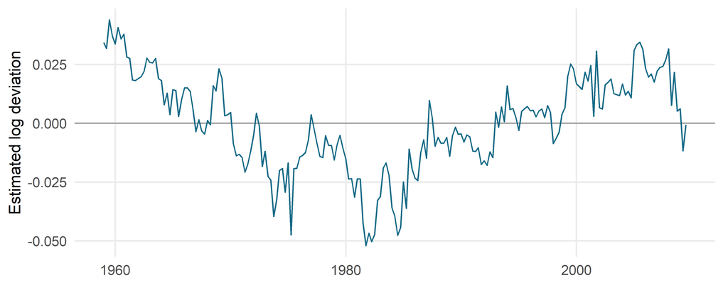

Slope **1.032** · $R^2=$ **0.9984** · EG **-2.589** vs. CV **-3.367**

## What happens when we change the augmentation?

| Lagged residual differences | Test rows | EG statistic | Reject at 5%? |
| --- | --- | --- | --- |
| 0 | 202 | -3.397 | Yes |
| 2 | 200 | -2.898 | No |
| 4 | 198 | -2.589 | No |
| 8 | 194 | -2.032 | No |

Same 203 levels observations and **-3.367** critical value.

Can we simply choose the zero-lag rejection?

## The zero-lag rejection leaves a warning in its residuals

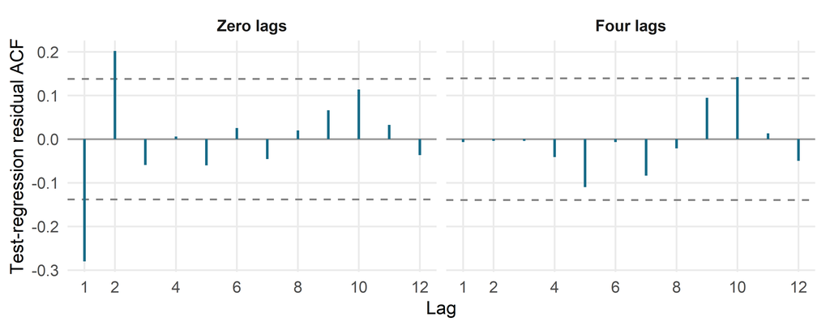

These are the test regression’s remaining residuals. Dashed bands are descriptive—not a joint whiteness test.

## This sample has not earned a validated economic ECM

The baseline **does not reject no cointegration** at 5%.

The zero-lag rejection is sensitive to augmentation and has weaker diagnostic support.

We have insufficient evidence here for an established stable relation. We have not shown that consumption and income are unrelated.

What would further investigation need to document?

# Act VI · Bring the story home

A relationship, a test, and a disciplined interpretation.

## What belongs in the empirical report?

1. **Data:** definitions, units, transformations, dates, frequency, vintage.
2. **I(1) assessment:** evidence and its limitations.
3. **Test:** normalization, deterministic terms, lags, matching reference values.
4. **Evidence:** statistic, decision, diagnostics, declared sensitivity.
5. **Interpretation:** justified dynamics and the claims that remain unresolved.

Could another analyst reproduce both your decision and your doubts?

## What Harry and Mouse taught us

**Cointegration:** I(1) levels can have an I(0) weighted relationship.

**Not enough:** correlation, matching trends, significance stars, or a causal story.

**Engle–Granger:** estimate the relation; test its residual with the right calibration.

**Error correction:** keep yesterday’s deviation alongside short-run changes.

**Economics:** motivate the relation, then let the evidence qualify the claim.

## Next: give each variable its own equation

$$\text{ARMA}\quad\longrightarrow\quad\text{ARDL}\quad\longrightarrow\quad\text{VAR}$$

**Module 11:** build a system in which each variable can respond to the others’ histories.

**Module 13:** return to error correction inside that system.

Looking ahead: with several variables, cointegrating rank counts independent stationary relationships. Johansen’s system approach asks about that rank.